# HUK Coding Challenge

2024-05-20

## Pakete laden

```r
library(farff)
library(tidyverse)
library(mlr3verse)
library(ggplot2)
library(lares)
library(extRemes)
library(DataExplorer)
```

## Daten einlesen

```r
# .arff einlesen
freq_data = readARFF("../datasets/freMTPL2freq.arff")
sev_data = readARFF("../datasets/freMTPL2sev.arff")

# join anhand von IDpol; behalte alle Beobachtungen mit Versicherungsanspruch
joined_data = right_join(freq_data, sev_data, by = join_by(IDpol == IDpol))
joined_data = joined_data[complete.cases(joined_data), ]
```

## Daten aufbereiten

- Berechne zunächst den gesamten Versicherungsanspruch je Kunden.

```r
total_claim_amount = joined_data %>%
  group_by(IDpol) %>%
  summarise(TotalClaimAmount = sum(ClaimAmount)) %>%
  select(IDpol, TotalClaimAmount)
```

- Behalte jeweils einen Feature-Vektor je Kunden (alle identisch) und join mit gesamten Versicherungsanspruch.
- Erstelle Zielvariable als gesamter Versicherungsanspruch durch Versicherungszeitraum in Jahren (TotalClaimAmount / Exposure).
- Entferne redundante Bestandteile der Zielvariablen (TotalClaimAmount, Exposure).
- Entferne redundante Feature (Density, Region).
- Entferne nicht benötigte Feature (ClaimNb, IDpol).

```r
insurance_data = joined_data %>%
  group_by(IDpol) %>%
  filter(row_number() == 1) %>%
  ungroup(IDpol) %>%
  select(-ClaimAmount) %>%
  full_join(total_claim_amount, by = join_by(IDpol)) %>%
  mutate(ClaimPerYear = TotalClaimAmount / Exposure) %>%
  select(-c(TotalClaimAmount, Exposure, ClaimNb, Density, Region, IDpol)) %>%
  mutate(VehGas = as.factor(VehGas))
```

## Explorative Analyse

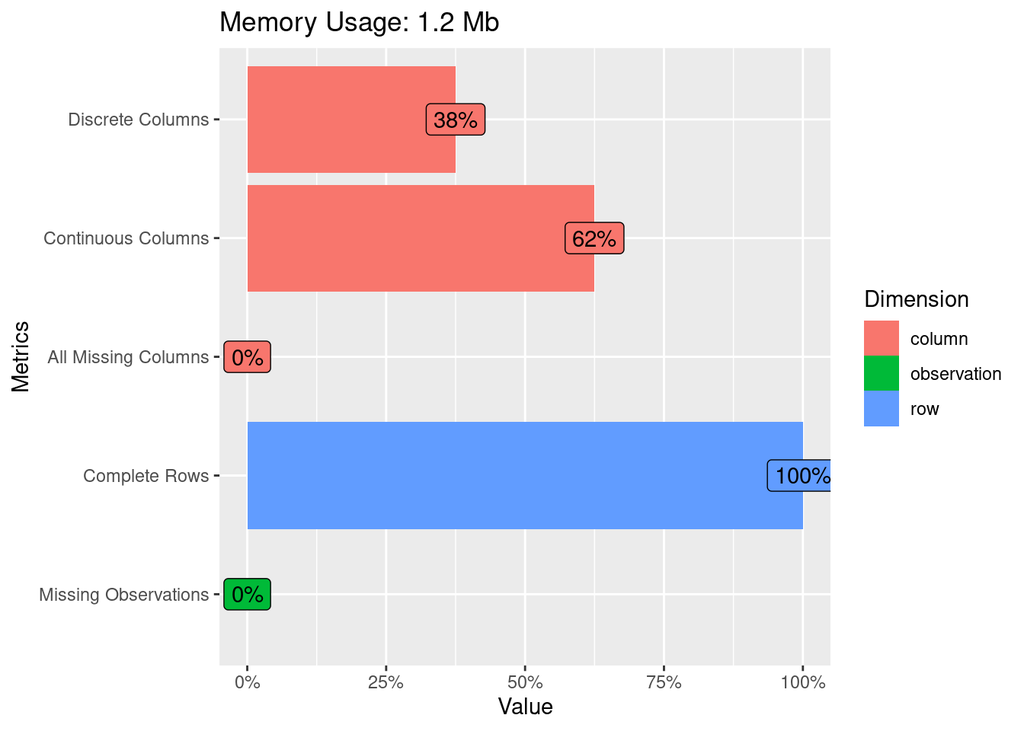

```r
plot_intro(insurance_data)
```

- Boxplot der Zielvariable zeigt einige extreme Ausreißer.

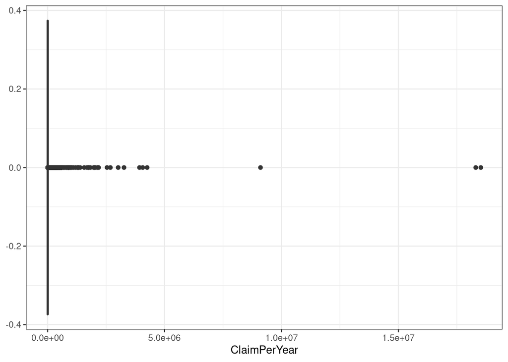

```r
ggplot(insurance_data, aes(x = ClaimPerYear)) +
  geom_boxplot() +
  theme_bw()
```

- Interquartilsabstand (25% bis 75% Quantil) beträgt jedoch nur 2224 EUR.
- Der höchste Versicherungsanspruch eines Kunden pro Jahr beträgt ganze 18.524.548 EUR.
- 90% aller Kunden nehmen Ansprüche von unter 9208 EUR pro Jahr in Anspruch.

```r
IQR(insurance_data$ClaimPerYear)
```

```
## [1] 2224.01
```

```r
range(insurance_data$ClaimPerYear)
```

```
## [1]        1 18524548
```

```r
quantile(round(insurance_data$ClaimPerYear), probs = seq(0, 1, 0.05))
```

```
##          0%          5%         10%         15%         20%         25%
##        1.00      117.00      319.00      595.45      872.00     1128.00
##         30%         35%         40%         45%         50%         55%
##     1128.00     1204.00     1204.00     1327.00     1504.00     1717.00
##         60%         65%         70%         75%         80%         85%
##     2014.00     2344.00     2751.00     3352.25     4300.00     5871.10
##         90%         95%        100%
##     9207.90    18910.15 18524548.00
```

- **Aufgrund der zentralen Bedeutung von hohen Versicherungsansprüchen für die Versicherungsgesellschaft können wir die Ausreißer hier NICHT entfernen. Diese sollten unbedingt mitmodelliert werden.**
- Gehen wir nun zur deskriptiven Zusammenhangsanalyse über.
- Innerhalb der erklärenden Variablen finden sich diverse Korrelationen, beispielsweise zwischen Alter des Fahrers und des Schadenfreiheitsrabattes, sowie zwischen Merkmalen des Fahrzeuges.

```r
corr_cross(insurance_data, # name of dataset
           max_pvalue = 0.05, # display only significant correlations (at 5% level)
           top = 10 # display top 10 couples of variables (by correlation coefficient)
)
```

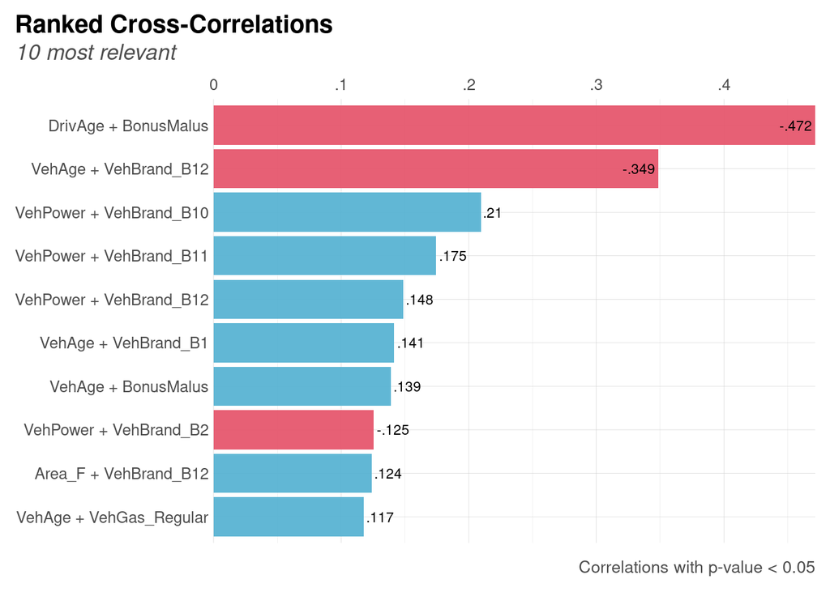

```r
corr_var(insurance_data, # name of dataset
         ClaimPerYear, # name of variable to focus on
         top = 5 # display top 5 correlations
)
```

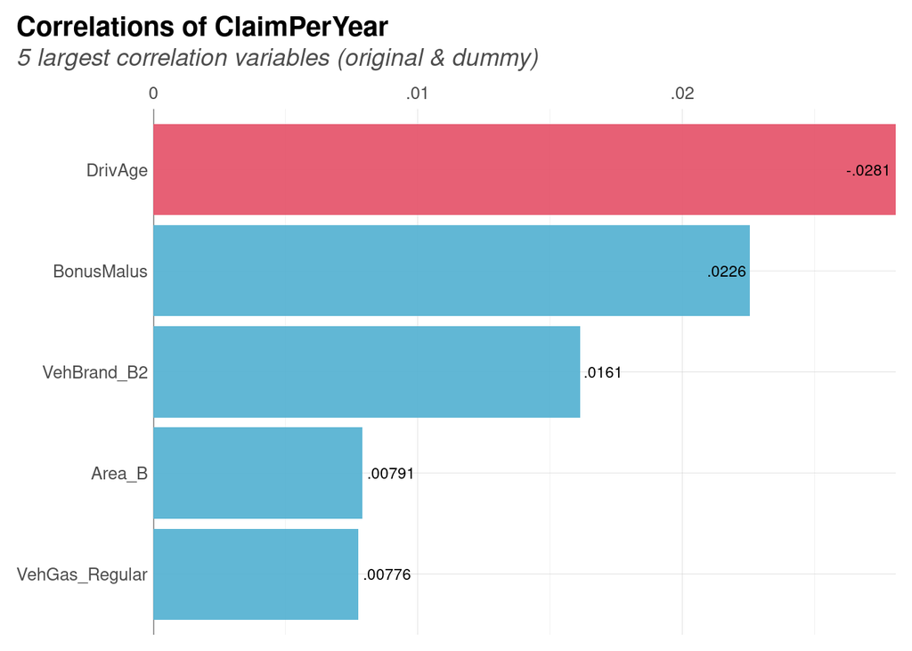

```r
feature_pred = x2y(insurance_data)
```

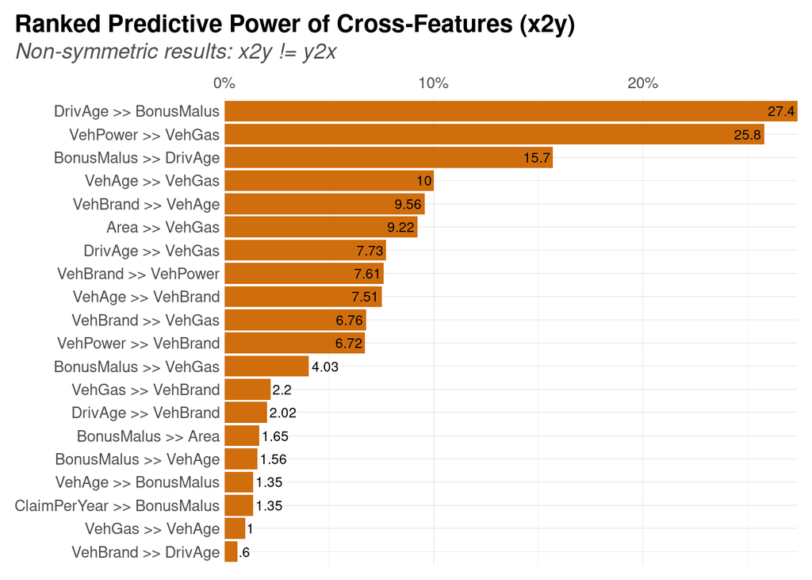

```r
plot(feature_pred)
```

- **Fazit:** Zwar lassen lineare Korrelationen nicht ausschließen, dass es nichtlineare Zusammenhänge gibt, jedoch sind die vorhandenen linearen Assoziationen nicht sehr vielversprechend für ein zu trainierendes Modell, welches einen multivariaten Zusammenhang beschreibt.

## Modellierung

### Extremwerte der Versicherungsansprüche

- Aufgrund der extrem rechtsschiefen Verteilung der Zielvariablen bietet sich eine Modellierung des Verteilungsrandes (mit sehr wenigen Werten) per Extremwertverteilung an (heavy Tail).
- Eine Möglichkeit ist eine generalisierte Paretoverteilung, um den Rand der Zielvariablen zu beschreiben.
- Hierzu wird eine Grenze (Threshold) benötigt, ab der ein Wert als zum Rand zugehörig modelliert wird.
- Im Folgenden wird iterativ getestet, welches Akaike-Information-Criterion (AIC) mit welcher Grenze assoziiert ist.

```r
insurance_df = data.frame(insurance_data)
threshold_vector = seq(5000, 1000000, 10000)
AIC_vector = lapply(threshold_vector, FUN = function(i) {
  fitGEV <- fevd(
    ClaimPerYear,
    data = insurance_df,
    type = "GP",
    threshold = i)
  return(2 * fitGEV$results$value + 2)}
)
```

- Ich benutze eine Heuristik im Sinne eines Ellbogenkriteriums bezüglich AIC: Ab Threshold von 250.000 beginnt der Fit sich nur graduell zu verbessern.

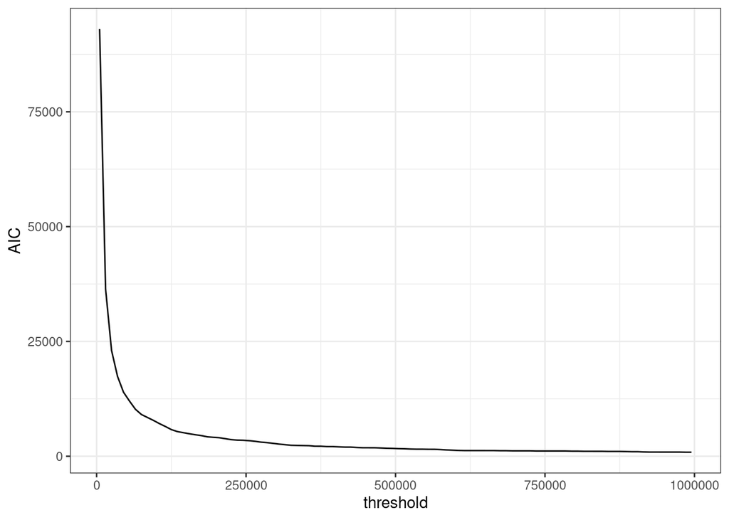

```r
threshold_df = data.frame(threshold_vector, unlist(AIC_vector))
ggplot(data.frame("threshold" = threshold_vector, "AIC" = unlist(AIC_vector))) +
  geom_line(aes(x = threshold, y = AIC)) +
  theme_bw()
```

- Die Grenze von 250000 EUR wird zur Schätzung der finalen Paretoverteilung benutzt.

```r
pareto <- fevd(
  ClaimPerYear,
  data = insurance_df,
  type = "GP",
  threshold = 250000)
pareto
```

```
##
## fevd(x = ClaimPerYear, data = insurance_df, threshold = 250000,
##     type = "GP")
##
## [1] "Estimation Method used: MLE"
##
##
##  Negative Log-Likelihood Value:  1707.318
##
##
##  Estimated parameters:
##        scale        shape
## 2.585352e+05 8.671754e-01
##
##  Standard Error Estimates:
##        scale        shape
## 4200.5157658    0.1504324
##
##  Estimated parameter covariance matrix.
##               scale        shape
## scale  1.764433e+07 -34.35220981
## shape -3.435221e+01   0.02262991
##
##  AIC = 3418.636
##
##  BIC = 3424.211
```

- Die empirischen Quantile stimmen sehr gut mit den theoretischen Quantilen überein.
- Die empirischen Quantile einer zusätzlichen, künstlichen Stichprobe (stochastisch!) liegen sehr nahe an den empirischen Quantilen aus unseren Daten.

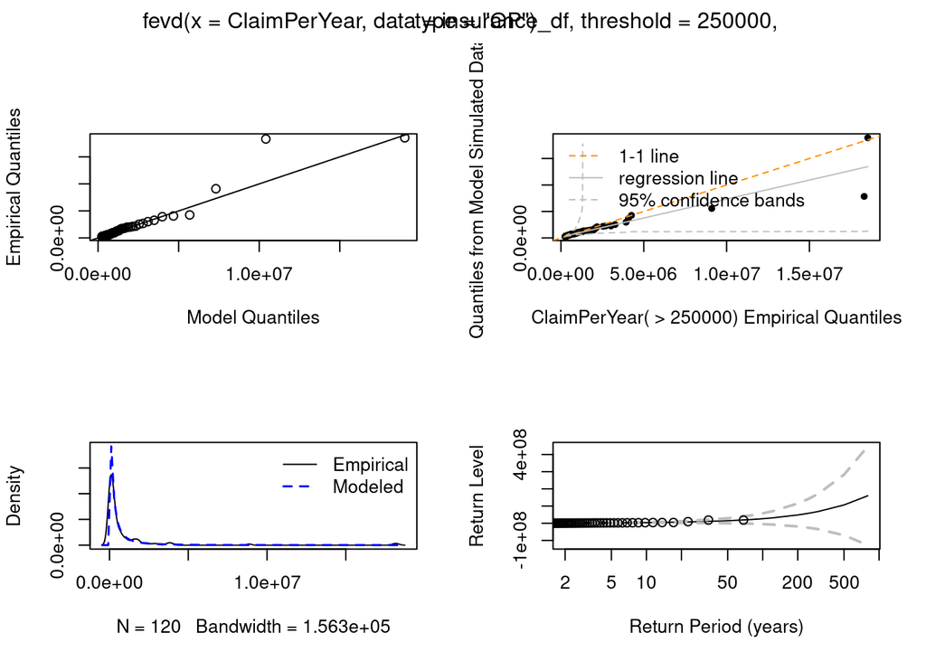

```r
set.seed(12)
plot(pareto)
```

### “Reguläre” Werte der Versicherungsansprüche

- Für Ansprüche kleiner als 250.000 EUR werden nun mehrere Regressionsmodelle via mlr3 trainiert.
- Ein Modell ohne Features (Durchschnitt) und ein lineares Modell mit allen Features wird als Baseline zur Referenz trainiert. Darüber hinaus trainieren wir einen Regressionsbaum (CART), ein k-nearest-Neighbor-Modell mit 7 Nachbarpunkten, eine Support Vector Machine, sowie einen Random Forest.
- Hierzu wird ein Benchmark von 6 Learnern erstellt (5-fach Kreuzvalidierung sowie One-Hot-Encoding kategorieller Features).
- Zur Illustration wird der Komplexitätsparameter bei rpart innerhalb des Benchmarks getuned.
- Auf eine aufwendige Hyperparameteroptimierung wird verzichtet, um den Rechenaufwand zu begrenzen. Darüber hinaus sollte ein Random Forest auch ohne Tuning passable Performance zeigen.

```r
model_data = insurance_data %>% filter(ClaimPerYear <= 250000)
quantile(round(model_data$ClaimPerYear), probs = seq(0.1, 1, 0.05))

model_data$VehGas = as.factor(model_data$VehGas)
model_data

tsk_insurance = as_task_regr(model_data, target = "ClaimPerYear", id = "insurance")
splits = partition(tsk_insurance)

# Auto Tuner für CART

at_rpart = auto_tuner(
  tuner = tnr("random_search"),
  learner = lrn("regr.rpart",
                cp = to_tune(1e-04, 1e-1, logscale = TRUE)),
  resampling = rsmp ("holdout"),
  measure = msr("regr.mse"),
  term_evals = 3)

learner_list = c(
  lrn("regr.featureless"),
  lrn("regr.lm"),
  at_rpart,
  lrn("regr.kknn"),
  lrn("regr.svm"),
  lrn("regr.ranger"))

resamplings = rsmp("cv", folds = 5)
learner_list = lapply(learner_list, FUN = function(x) {po("encode") %>>% x})
design = benchmark_grid(tsk_insurance, learner_list, resamplings)
bmr = benchmark(design)
aggr = bmr$aggregate()
aggr
```

```
##    nr   task_id              learner_id resampling_id iters  regr.mse
## 1:  1 insurance encode.regr.featureless            cv     5 209731150
## 2:  2 insurance          encode.regr.lm            cv     5 209237928
## 3:  3 insurance encode.regr.rpart.tuned            cv     5 209731150
## 4:  4 insurance        encode.regr.kknn            cv     5 257317938
## 5:  5 insurance         encode.regr.svm            cv     5 215560860
## 6:  6 insurance      encode.regr.ranger            cv     5 210532184
## Hidden columns: resample_result
```

- Nicht überraschend finden wir kein einziges passendes Modell; der reine Durchschnitt der Zielvariable als Baseline zeigt eine ähnliche Performance wie CART oder ein Random Forest!
- Als Illustration dient die Vorhersage des linearen Modells mit allen Features auf ungesehenen Testdaten, welches ähnlich wie alle anderen Modelle abschneidet: Wir verzeichnen extrem hohe Residuen.
- Dementsprechend erübrigt sich eine Analyse von Feature-Importance und Feature-Effects innerhalb eines “besten” Modells.

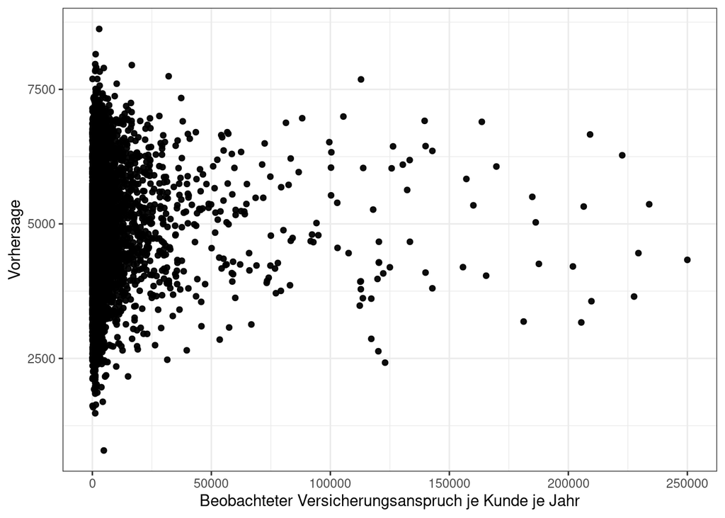

```r
learner = lrn("regr.lm")
learner$train(tsk_insurance, splits$train)
predictions = learner$predict(tsk_insurance, splits$test)

ggplot(predictions, aes(x = truth, y = response)) +
  geom_point() +
  theme_bw() +
  xlab("Beobachteter Versicherungsanspruch je Kunde je Jahr") +
  ylab("Vorhersage")
```

- Ich schlussfolgere, dass die Schätzung einer bedingten Dichte aufgrund fehlender Zusammenhänge hier nicht zum Ziel führt.
- Dass weitere Ausreißer (beispielsweise im Bereich von 9000 EUR und 250000) das Modell verzerren, erscheint auch unplausibel, da robuste Techniken wie CART oder Random Forests ebenso sehr schlecht vorhersagen.

### Mischverteilung

- Es verbleibt die Möglichkeit, die marginale Dichte der Zielvariable zu modellieren; auch deshalb, weil für unsere Extremwerterteilung > 250.000 EUR eine passende theoretische Verteilung gefunden werden konnte.
- Betrachten wir zunächst die empirische, marginale Verteilung der Zielvariable.

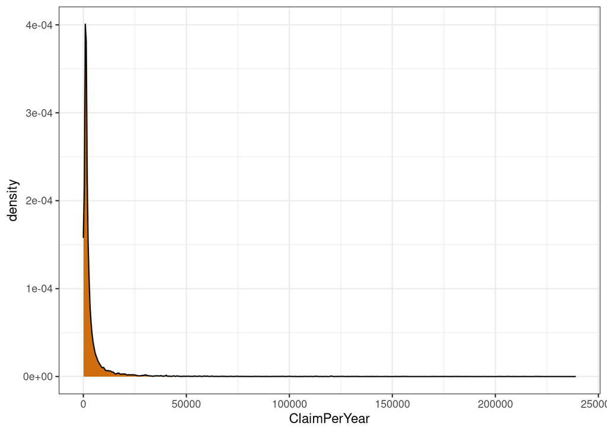

```r
claims_lower = model_data %>%
  filter(ClaimPerYear < 250000)

ggplot(claims_lower, aes(x = ClaimPerYear)) +
  geom_density() +
  theme_bw()
```

- Aufgrund der großen Datenmenge können wir hier auch auf eine empirische CDF zurückgreifen.

```r
find_empirical_dist = function(x) {
  n = length(x)
  sorted_x = sort(x)
  cumsum_frac = seq(1:n) / n
  emp_dist = data.frame(x = sorted_x, y = cumsum_frac)
  return(emp_dist)
}

empiricalProb = function(quantile, dist) {
  return(sum(dist$x <= quantile) / nrow(dist))
}
```

- Beispiel: Die Wahrscheinlichkeit, dass ein Kunde pro Jahr einen Versicherungsanspruch zwischen 3000 und 4000 EUR besitzt beträgt etwa 6%.

```r
emp_dist = find_empirical_dist(model_data$ClaimPerYear)
empiricalProb(4000, emp_dist) - empiricalProb(3000, emp_dist)
```

```
## [1] 0.0631244
```

- Für die Wahrscheinlichkeiten für einen Versicherungsanspruch je Kunde je Jahr haben wir nun zwei unterschiedliche Verteilungen mit geschätzten a-priori-Wahrscheinlichkeiten von 99.5%, dass ein Versicherungsanspruch < 250.000 EUR ist, sowie von 0.5%, dass ein Versicherungsanspruch > 250.000 EUR ist.

```r
# unter 250.000
p = nrow(model_data) / nrow(insurance_data)
p
```

```
## [1] 0.9951892
```

```r
# über 250.000
1-p
```

```
## [1] 0.004810776
```

- Die zusammgensetzte Mischverteilung ist ein durch die a-priori-Wahrscheinlichkeiten gewichteter Durchschnitt der Verteilungen.

$$\begin{equation}
\text{CDF}(\text{ClaimPerYear} = x) = 0.995 \cdot
\text{CDF}_{\text{empirisch}}(x) + 0.005 \cdot
\text{CDF}_{\text{Pareto}}(x)
\end{equation}$$

## Wirtschaftliche Umsetzung und Handlungsempfehlungen

- Die Versicherungsgesellschaft kann nun erwartete Verluste auf die Kunden umlegen.
- Da einzelnen Kundenmerkmale keine Vorhersagekraft bieten, können wir (noch) nicht zwischen Kunden preislich diskriminieren.
- Hierzu sollten zusätzliche Kundenmerkmale eingeholt werden. Ausreichend Datenpunkte sind bereits vorhanden, d.h. mehr Daten der gleichen Art zu sammeln, wird keine Verbesserung unsererer Modelle liefern.
- Die zusammgesetzte Verteilung kann unter Umständen noch weiter optimiert werden:
  - Schätzung theoretischer Verteilungen für “reguläre” Versicherungsansprüche.
  - Weitere Optimierung der Threshold.
  - Einteilung der Versicherungsansprüche je Kunde je Jahr in mehr Segmente.
- Darüber hinaus können wir andere Modellierungsansätze prüfen, die für die Versicherungsgesellschaft relevant sein können:
  - Die Wahrscheinlichkeit, dass ein Kunde überhaupt einen Schaden geltend macht.
  - Die Häufigkeit eines Schadens je Kunde je Jahr.